# PPOL670 | Applications in Supervised Machine Learning

Week 8

# Overview

In this notebook, we’ll apply the machine learning concepts covered in the supervised learning lecture. Note that there are many libraries that can perform the methods that we reviewed in class, but we’ll focus here on using the `caret` package to perform these operations.

# Data

The following data contains information regarding weather or not someone has health coverage. The outcome of interest is whether of not an individual has healthcare coverage or not. The available predictive features capture socio-economic and descriptive factors.

```r
set.seed(123)
dat = suppressMessages(read_csv("Data/health-coverage.csv")) %>%
  sample_n(5000) # Only taking a random sample of the data so the models run quicker
head(dat) # Peek at the data just to make sure everything was read in correctly.
```

| coverage | age | wage | cit | mar | educ | race |
| --- | --- | --- | --- | --- | --- | --- |
| No_Coverage | 26 | 14500 | Citizen | Married | HS Degree | White |
| Coverage | 36 | 120000 | Non-citizen | Married | Undergraduate Degree | White |
| No_Coverage | 42 | 0 | Citizen | Never Married | HS Degree | Black |
| Coverage | 61 | 61000 | Citizen | Married | HS Degree | White |
| Coverage | 74 | 0 | Citizen | Divorced | HS Degree | White |
| No_Coverage | 36 | 25000 | Citizen | Married | HS Degree | White |

# Split the Sample: Training and test data

Before event looking at the data, let’s split the sample up into a training and test dataset. We’ll completely hold off on viewing the test data, so as not to bias our development of the learning model.

```r
index = createDataPartition(dat$coverage,p=.8,list=F)
train_data = dat[index,] # Use 80% of the data as training data
test_data = dat[-index,] # holdout 20% as test data

dim(train_data)
```

```
[1] 4001    7
```

```r
dim(test_data)
```

```
[1] 999   7
```

# Examine the data

```r
skimr::skim(train_data)
```

```
Skim summary statistics
 n obs: 4001
 n variables: 7

── Variable type:character ──────────────────────────────────────────────────────────────────────────────────────────────
 variable missing complete    n min max empty n_unique
      cit       0     4001 4001   7  11     0        2
 coverage       0     4001 4001   8  11     0        2
     educ       0     4001 4001   9  20     0        4
      mar       0     4001 4001   7  13     0        5
     race       0     4001 4001   5  23     0        8

── Variable type:integer ────────────────────────────────────────────────────────────────────────────────────────────────
 variable missing complete    n     mean       sd p0 p25  p50   p75   p100     hist
      age       0     4001 4001    43.6     17.28 16  29   42    56     92 ▇▇▆▇▆▃▂▁
     wage       0     4001 4001 20149.81 39837.98  0   0 3600 27000 419000 ▇▁▁▁▁▁▁▁
```

Visualize the distribution for each variable.

First, let’s look at the categorical variables.

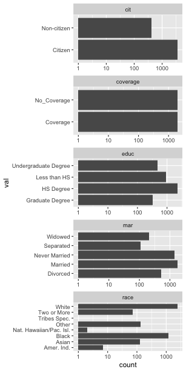

```r
train_data %>%
  select_if(is.character) %>%
  gather(var,val) %>%
  ggplot(aes(val)) +
  geom_bar() +
  scale_y_log10() +
  facet_wrap(~var,scales="free",ncol=1) +
  coord_flip()
```

Few things to note:

- Balanced classes on the outcome
- large representation of whites in the data.
- Good variation on maritial outcomes and education

Second, let’s look at the distribution of the continuous variables

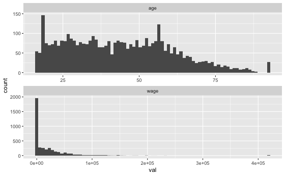

```r
train_data %>%
  select_if(is.numeric) %>%
  gather(var,val) %>%
  ggplot(aes(val)) +
  geom_histogram(bins = 75) +
  facet_wrap(~var,scales="free",ncol=1)
```

Things to note:

- wage is right skewed. There appears to an outlier making a lot of the money. This outlier could cause problems.
- Good distribution on the age variable.
- The scales for both these variables will have to be adjusted.

Let’s peek more closely at the distribution of wealth in the sample.

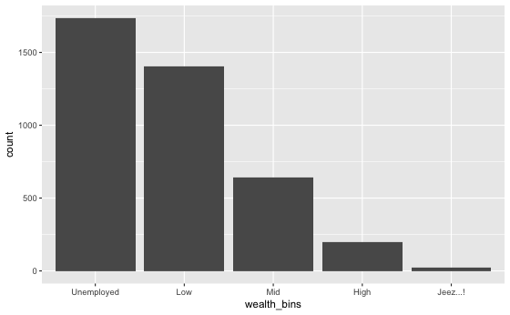

```r
train_data %>%
  mutate(wealth_bins = case_when(
    wage == 0 ~ "Unemployed",
    wage > 0 & wage<= 30000 ~ "Low",
    wage > 30000 & wage<= 75000 ~ "Mid",
    wage > 75000 & wage<= 200000 ~ "High",
    wage > 200000 ~ "Jeez...!",
  )) %>%
  mutate(wealth_bins = fct_infreq(wealth_bins)) %>%
  ggplot(aes(wealth_bins)) +
  geom_bar()
```

There are a lot of individuals that report 0 income (Unemployed). What is the age distribution for those individuals?

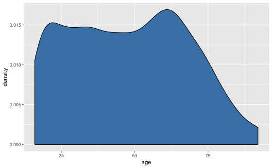

```r
train_data %>%
  filter(wage==0) %>%
  ggplot(aes(age)) +
  geom_density(fill="steelblue")
```

# Pre-process the Data

What do we need to do?

- Categorical variables to dummies
- We’ll likely need to log wage to deal with skew.
- Scale age and wage (so that they fall into a 0 to 1 range)
- No need to impute missing values. All the data is there.

First, convert the wage scale.

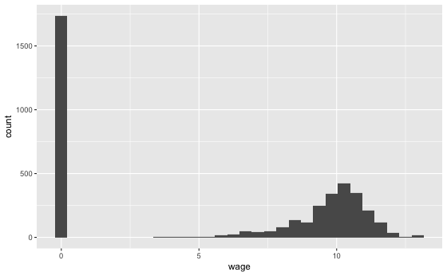

```r
# Mutate the features
convert_wage <- . %>% mutate(employed = ifelse(wage==0,"yes","no"),
                             wage = log(wage+1))

# Apply to both the training and test data
train_data2 <- train_data %>%  convert_wage()
test_data2 <- test_data %>%  convert_wage()

# Visualize the transformation
train_data2 %>%
  ggplot(aes(wage)) +
  geom_histogram()
```

```r
rcp <-
  recipe(coverage~.,train_data2) %>%
  step_dummy(all_nominal(),-all_outcomes()) %>%
  step_range(wage,age) %>%  # Normalize scale
  prep()


# Apply the recipe to the training and test data
train_data3 <- bake(rcp,train_data2)
test_data3 <- bake(rcp,test_data2)
```

Check that our pre-processing worked.

```r
head(train_data3)
```

| coverage | age | wage | cit_Non.citizen | mar_Married | mar_Never.Married | mar_Separated | mar_Widowed | educ_HS.Degree | educ_Less.than.HS | educ_Undergraduate.Degree | race_Asian | race_Black | race_Nat..Hawaiian.Pac..Isl. | race_Other | race_Tribes.Spec. | race_Two.or.More | race_White | employed_yes |
| --- | --- | --- | --- | --- | --- | --- | --- | --- | --- | --- | --- | --- | --- | --- | --- | --- | --- | --- |
| No_Coverage | 0.1315789 | 0.7401705 | 0 | 1 | 0 | 0 | 0 | 1 | 0 | 0 | 0 | 0 | 0 | 0 | 0 | 0 | 1 | 0 |
| Coverage | 0.2631579 | 0.9034135 | 1 | 1 | 0 | 0 | 0 | 0 | 0 | 1 | 0 | 0 | 0 | 0 | 0 | 0 | 1 | 0 |
| No_Coverage | 0.3421053 | 0.0000000 | 0 | 0 | 1 | 0 | 0 | 1 | 0 | 0 | 0 | 1 | 0 | 0 | 0 | 0 | 0 | 1 |
| Coverage | 0.5921053 | 0.8511480 | 0 | 1 | 0 | 0 | 0 | 1 | 0 | 0 | 0 | 0 | 0 | 0 | 0 | 0 | 1 | 0 |
| Coverage | 0.7631579 | 0.0000000 | 0 | 0 | 0 | 0 | 0 | 1 | 0 | 0 | 0 | 0 | 0 | 0 | 0 | 0 | 1 | 1 |
| No_Coverage | 0.2631579 | 0.7822464 | 0 | 1 | 0 | 0 | 0 | 1 | 0 | 0 | 0 | 0 | 0 | 0 | 0 | 0 | 1 | 0 |

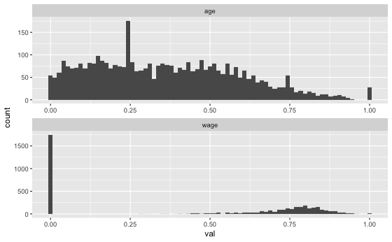

```r
train_data3 %>%
  select(wage,age) %>%
  gather(var,val) %>%
  ggplot(aes(val)) +
  geom_histogram(bins = 75) +
  facet_wrap(~var,scales="free",ncol=1)
```

# Cross-validation

When comparing different machine learning models, we want to make sure we’re making a fair and equal comparison. One way that random chance can sneak into our assessments of model fit is through cross-validation. We want to make sure that we’re cross-validating the data on the exact same data partitions.

`caret` makes this ease to do. Let’s use the k-fold cross-validation method with 10 folds in the data.

```r
set.seed(1988) # set a seed for replication purposes

folds <- createFolds(train_data3$coverage, k = 10) # Partition the data into 10 equal folds

sapply(folds,length)
```

```
Fold01 Fold02 Fold03 Fold04 Fold05 Fold06 Fold07 Fold08 Fold09 Fold10
   400    400    400    400    401    401    400    400    400    399
```

Now, let’s use the `trainControl()` function from `caret` to set up our validation conditions

```r
control_conditions <-
  trainControl(method='cv', # K-fold cross validation
               summaryFunction = twoClassSummary, # Need this b/c it's a classification problem
               classProbs = TRUE, # Need this b/c it's a classification problem
               index = folds # The indices for our folds (so they are always the same)
  )
```

We’ll now use this same cross-validation object for everything that we do.

# Models

Let’s explore the different models that we covered in the lecture using the same package framework. As we saw last time in class, `caret` facilitates this task nicely.

## K-Nearest Neighbors

> Remember: these algorithms are computationally demanding, so they can take a little time to run depending on the power of your machine

```r
mod_knn <-
  train(coverage ~ ., # Equation (outcome and everything else)
        data=train_data3, # Training data
        method = "knn", # K-Nearest Neighbors Algorithm
        metric = "ROC", # area under the curve
        trControl = control_conditions
  )
```

Let’s look at the performance plots. What do we see?

```r
mod_knn
```

```
k-Nearest Neighbors

4001 samples
  18 predictor
   2 classes: 'Coverage', 'No_Coverage'

No pre-processing
Resampling: Cross-Validated (10 fold)
Summary of sample sizes: 400, 400, 400, 400, 401, 401, ...
Resampling results across tuning parameters:

  k  ROC        Sens       Spec
  5  0.7364540  0.6678890  0.6992554
  7  0.7381862  0.6665597  0.6926391
  9  0.7403555  0.6694419  0.6991465

ROC was used to select the optimal model using the largest value.
The final value used for the model was k = 9.
```

- `caret` has default settings that auto explore different tunning parameters for the model.
- We can easily plot these tuning features using the standard plot functions (these function have been over-ridden in R)

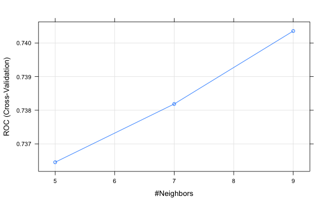

```r
plot(mod_knn)
```

```r
# Draw out the best model (the one with the best performance)
mod_knn$finalModel
```

```
9-nearest neighbor model
Training set outcome distribution:

   Coverage No_Coverage
       2003        1998
```

```r
pred <- predict(mod_knn,newdata = test_data3)
confusionMatrix(table(pred,test_data3$coverage))
```

```
Confusion Matrix and Statistics


pred          Coverage No_Coverage
  Coverage         353         126
  No_Coverage      147         373

               Accuracy : 0.7267
                 95% CI : (0.698, 0.7542)
    No Information Rate : 0.5005
    P-Value [Acc > NIR] : <2e-16

                  Kappa : 0.4535
 Mcnemar's Test P-Value : 0.2261

            Sensitivity : 0.7060
            Specificity : 0.7475
         Pos Pred Value : 0.7370
         Neg Pred Value : 0.7173
             Prevalence : 0.5005
         Detection Rate : 0.3534
   Detection Prevalence : 0.4795
      Balanced Accuracy : 0.7267

       'Positive' Class : Coverage
```

Now, let’s say we wanted to adjust the tunning parameters. We can explore different model tunings by using the `tuneGrid` argument.

```r
knn_tune = expand.grid(k = c(1,3,10,50))
knn_tune
```

| k |
| --- |
| 1 |
| 3 |
| 10 |
| 50 |

```r
mod_knn2 <-
  train(coverage ~ ., # Equation (outcome and everything else)
        data=train_data3, # Training data
        method = "knn", # K-Nearest Neighbors Algorithm
        metric = "ROC", # area under the curve
        tuneGrid = knn_tune, # add the tuning parameters here
        trControl = control_conditions
  )
```

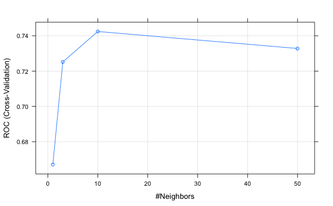

```r
plot(mod_knn2)
```

Out-of-sample predictive performance.

```r
pred <- predict(mod_knn2,newdata = test_data3)
confusionMatrix(table(pred,test_data3$coverage))
```

```
Confusion Matrix and Statistics


pred          Coverage No_Coverage
  Coverage         345         127
  No_Coverage      155         372

               Accuracy : 0.7177
                 95% CI : (0.6887, 0.7455)
    No Information Rate : 0.5005
    P-Value [Acc > NIR] : <2e-16

                  Kappa : 0.4355
 Mcnemar's Test P-Value : 0.1079

            Sensitivity : 0.6900
            Specificity : 0.7455
         Pos Pred Value : 0.7309
         Neg Pred Value : 0.7059
             Prevalence : 0.5005
         Detection Rate : 0.3453
   Detection Prevalence : 0.4725
      Balanced Accuracy : 0.7177

       'Positive' Class : Coverage
```

## Classification and Regression Trees (CART)

```r
mod_cart <-
  train(coverage ~ ., # Equation (outcome and everything else)
        data=train_data3, # Training data
        method = "rpart", # Classification Tree
        metric = "ROC", # area under the curve
        trControl = control_conditions
  )
```

```r
mod_cart
```

```
CART

4001 samples
  18 predictor
   2 classes: 'Coverage', 'No_Coverage'

No pre-processing
Resampling: Cross-Validated (10 fold)
Summary of sample sizes: 400, 400, 400, 400, 401, 401, ...
Resampling results across tuning parameters:

  cp          ROC        Sens       Spec
  0.01484818  0.7535952  0.6712184  0.7509749
  0.19569570  0.6477302  0.4076725  0.8817203
  0.22722723  0.6403592  0.4889260  0.7857247

ROC was used to select the optimal model using the largest value.
The final value used for the model was cp = 0.01484818.
```

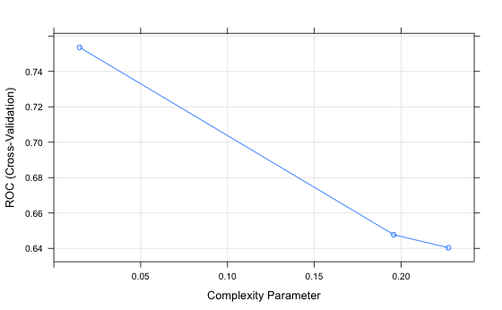

```r
plot(mod_cart)
```

Shallower trees converge to a coin flip. The deepest tree appears to be the bets

Let’s visualize the decision tree…

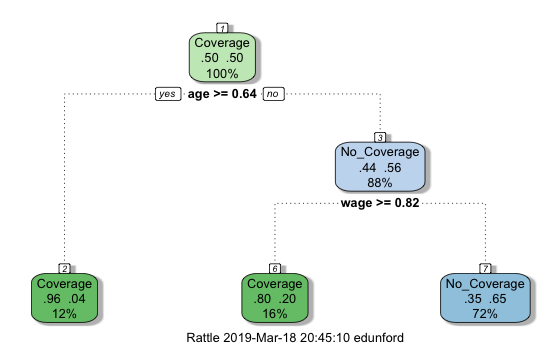

```r
# This tree goes really deep
fancyRpartPlot(mod_cart$finalModel)
```

```r
print(mod_cart$finalModel)
```

```
n= 4001

node), split, n, loss, yval, (yprob)
      * denotes terminal node

1) root 4001 1998 Coverage (0.50062484 0.49937516)
  2) age>=0.6381579 495   18 Coverage (0.96363636 0.03636364) *
  3) age< 0.6381579 3506 1526 No_Coverage (0.43525385 0.56474615)
    6) wage>=0.8183576 645  127 Coverage (0.80310078 0.19689922) *
    7) wage< 0.8183576 2861 1008 No_Coverage (0.35232436 0.64767564) *
```

Let’s free the CART to grow deeper

```r
tune_cart2 <- expand.grid(cp = c(0.0010281)) # Complexity Parameter (how "deep" our trees should grow)
mod_cart2 <-
  train(coverage ~ ., # Equation (outcome and everything else)
        data=train_data3, # Training data
        method = "rpart", # Classification Tree
        metric = "ROC", # area under the curve
        tuneGrid = tune_cart2, # Tuning parameters
        trControl = control_conditions
  )
```

The Model becomes far more complex!

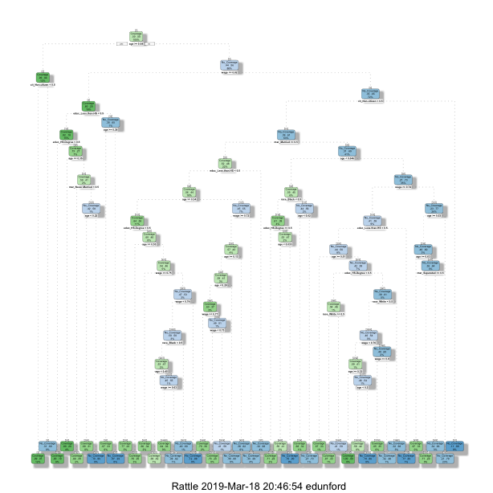

```r
fancyRpartPlot(mod_cart2$finalModel)
```

Out-of-sample predictive performance for the shallower tree

```r
pred <- predict(mod_cart,newdata = test_data3)
confusionMatrix(table(pred,test_data3$coverage))
```

```
Confusion Matrix and Statistics


pred          Coverage No_Coverage
  Coverage         250          35
  No_Coverage      250         464

               Accuracy : 0.7147
                 95% CI : (0.6856, 0.7425)
    No Information Rate : 0.5005
    P-Value [Acc > NIR] : < 2.2e-16

                  Kappa : 0.4297
 Mcnemar's Test P-Value : < 2.2e-16

            Sensitivity : 0.5000
            Specificity : 0.9299
         Pos Pred Value : 0.8772
         Neg Pred Value : 0.6499
             Prevalence : 0.5005
         Detection Rate : 0.2503
   Detection Prevalence : 0.2853
      Balanced Accuracy : 0.7149

       'Positive' Class : Coverage
```

Out-of-sample predictive performance for the deeper tree

```r
pred <- predict(mod_cart2,newdata = test_data3)
confusionMatrix(table(pred,test_data3$coverage))
```

```
Confusion Matrix and Statistics


pred          Coverage No_Coverage
  Coverage         348         103
  No_Coverage      152         396

               Accuracy : 0.7447
                 95% CI : (0.7165, 0.7715)
    No Information Rate : 0.5005
    P-Value [Acc > NIR] : < 2.2e-16

                  Kappa : 0.4895
 Mcnemar's Test P-Value : 0.002648

            Sensitivity : 0.6960
            Specificity : 0.7936
         Pos Pred Value : 0.7716
         Neg Pred Value : 0.7226
             Prevalence : 0.5005
         Detection Rate : 0.3483
   Detection Prevalence : 0.4515
      Balanced Accuracy : 0.7448

       'Positive' Class : Coverage
```

Depth buys us something!

## Random Forest

```r
mod_rf <-
  train(coverage ~ ., # Equation (outcome and everything else)
        data=train_data3, # Training data
        method = "ranger", # random forest (ranger is much faster than rf)
        metric = "ROC", # area under the curve
        importance = 'impurity', # For variable importance metric (see below)
        trControl = control_conditions
  )
```

There are three tunning parameters in this model:

- `mtry`: the number of predictors that we’ll randomly select.
- `splitrule`: the way we determine how the nodes should be split
  - `gini` = node purity (see class lecture)
  - `extratrees` = doesn’t bag, randomly select vars, but just randomly split, accept the best split. (Short for “Extremely Randomize Trees”)
- ‘min.node.size’: the minimum number of observations that can be in each terminal node (default fixes this at 1)

```r
mod_rf
```

```
Random Forest

4001 samples
  18 predictor
   2 classes: 'Coverage', 'No_Coverage'

No pre-processing
Resampling: Cross-Validated (10 fold)
Summary of sample sizes: 400, 400, 400, 400, 401, 401, ...
Resampling results across tuning parameters:

  mtry  splitrule   ROC        Sens       Spec
   2    gini        0.8101478  0.7038890  0.7659915
   2    extratrees  0.7806733  0.7088819  0.7088209
  10    gini        0.7944539  0.7028357  0.7330660
  10    extratrees  0.7890131  0.7007263  0.7297305
  18    gini        0.7855932  0.6952369  0.7232227
  18    extratrees  0.7827187  0.6950688  0.7219442

Tuning parameter 'min.node.size' was held constant at a value of 1
ROC was used to select the optimal model using the largest value.
The final values used for the model were mtry = 2, splitrule = gini and min.node.size = 1.
```

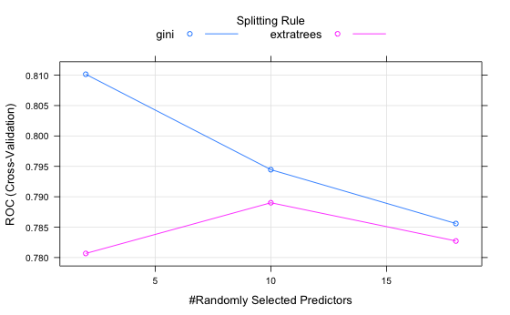

```r
plot(mod_rf)
```

Out-of-sample predictive performance.

```r
pred <- predict(mod_rf,newdata = test_data3)
confusionMatrix(table(pred,test_data3$coverage))
```

```
Confusion Matrix and Statistics


pred          Coverage No_Coverage
  Coverage         376         129
  No_Coverage      124         370

               Accuracy : 0.7467
                 95% CI : (0.7186, 0.7735)
    No Information Rate : 0.5005
    P-Value [Acc > NIR] : <2e-16

                  Kappa : 0.4935
 Mcnemar's Test P-Value : 0.8014

            Sensitivity : 0.7520
            Specificity : 0.7415
         Pos Pred Value : 0.7446
         Neg Pred Value : 0.7490
             Prevalence : 0.5005
         Detection Rate : 0.3764
   Detection Prevalence : 0.5055
      Balanced Accuracy : 0.7467

       'Positive' Class : Coverage
```

### Variable Importance

Random forest models can be difficult to interpret. That said, we can extract which variables are most important from the feature set to see which factors did the heavy lifting.

Visualize it.

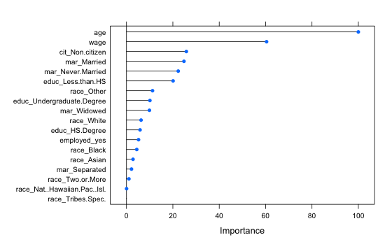

```r
plot(varImp(mod_rf))
```

### Partial Dependence Plots

The partial dependence plot (short PDP or PD plot) shows the marginal effect a feature has on the predicted outcome of a machine learning model. A partial dependence plot can show whether the relationship between the target and a feature is linear, monotonous or more complex.

Let’s look at age. The most predictive feature in our model. We can see that as people get older, they are far more likely to have healthcare coverage.

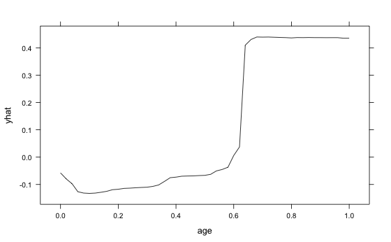

```r
partial(mod_rf,pred.var = "age",plot = T)
```

We can stack these plots to liook at the different effects.

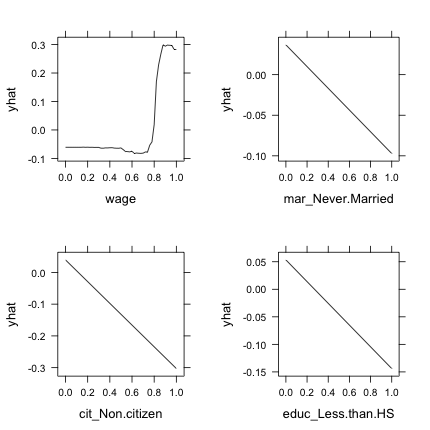

```r
grid.arrange(
  partial(mod_rf,pred.var = "wage",plot = T),
  partial(mod_rf,pred.var = "mar_Never.Married",plot = T),
  partial(mod_rf,pred.var = "cit_Non.citizen", plot = T),
  partial(mod_rf,pred.var = "educ_Less.than.HS",plot = T)
)
```

We can represent the joint relationship between these two variables (note that this takes a while when you have continuous variables…)

```r
pdp_imp_vars <- partial(mod_rf,pred.var = c("mar_Never.Married","educ_Less.than.HS"))
pdp_imp_vars
```

| mar_Never.Married | educ_Less.than.HS | yhat |
| --- | --- | --- |
| 0 | 0 | 0.08858765 |
| 1 | 0 | -0.05792849 |
| 0 | 1 | -0.12267694 |
| 1 | 1 | -0.21682156 |

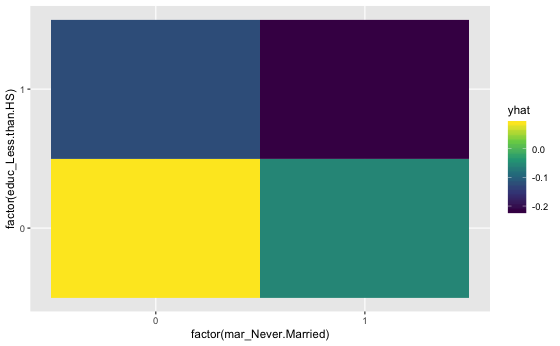

```r
pdp_imp_vars %>%
  ggplot(aes(factor(mar_Never.Married),factor(educ_Less.than.HS),fill=yhat)) +
  geom_tile() +
  scale_fill_viridis_c()
```

# Model Comparison

How did the different methods perform? Which one did the best?

```r
# Organize all model imputs as a list.
mod_list <-
  list(
    knn1 = mod_knn,
    knn2 = mod_knn2,
    cart1 = mod_cart,
    cart2 = mod_cart2,
    rf = mod_rf
  )

# Resamples allows us to compare model output
resamples(mod_list)
```

```
Call:
resamples.default(x = mod_list)

Models: knn1, knn2, cart1, cart2, rf
Number of resamples: 10
Performance metrics: ROC, Sens, Spec
Time estimates for: everything, final model fit
```

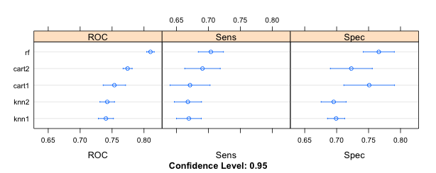

```r
dotplot(resamples(mod_list))
```